# PC_population_level

Thomas Francisco

2024-03-21

The raw vcf file contains 11374 SNPs, 490 individuals and 8.76 % of missing data

```r
vcf <- read.vcfR("C:/Users/tfrancisco/Documents/Thèse/Data/Espèces/Taxus_baccata/genetic/filtered_T_11374SNP_490IND_ADAPCON_GENTREE.vcf", verbose = FALSE,convertNA=T)
meta_data_vcf=read.csv("C:/Users/tfrancisco/Documents/Thèse/Data/Espèces/Taxus_baccata/Samples/samples_taxus_baccata_adapcon_gentree.csv",h=T,sep=";",dec=",")
```

1. Population structure dataset

Filtering of DP, allele_balance, Na_snp, Na_indiv

```r
min_dp= 7
max_dp=250
Allele_balance_min= .2
Allele_balance_max= .8
Na_snp=0.85 #% of Na per SNP,  0.85 = we kept only snp with less than 15% of missing data
Na_indiv=0.15#% of Na per individual, 0.15 = we kept only individuals with less than 15% of missing data


vcf_filter_structure <- vcf %>%
  hard_filter(depth=min_dp ) %>%
  max_depth(maxdepth =max_dp )%>%
  filter_allele_balance(min.ratio=Allele_balance_min,max.ratio=Allele_balance_max)%>%
  missing_by_snp(cutoff=Na_snp)%>%
  missing_by_sample( cutoff =Na_indiv )
```

```
## 1.08% of genotypes fall below a read depth of 7 and were converted to NA
```

```
## no genotype quality cutoff provided, exploratory visualization will be generated.
```

```
## maxdepth cutoff is specified, filtered vcfR object will be returned
```

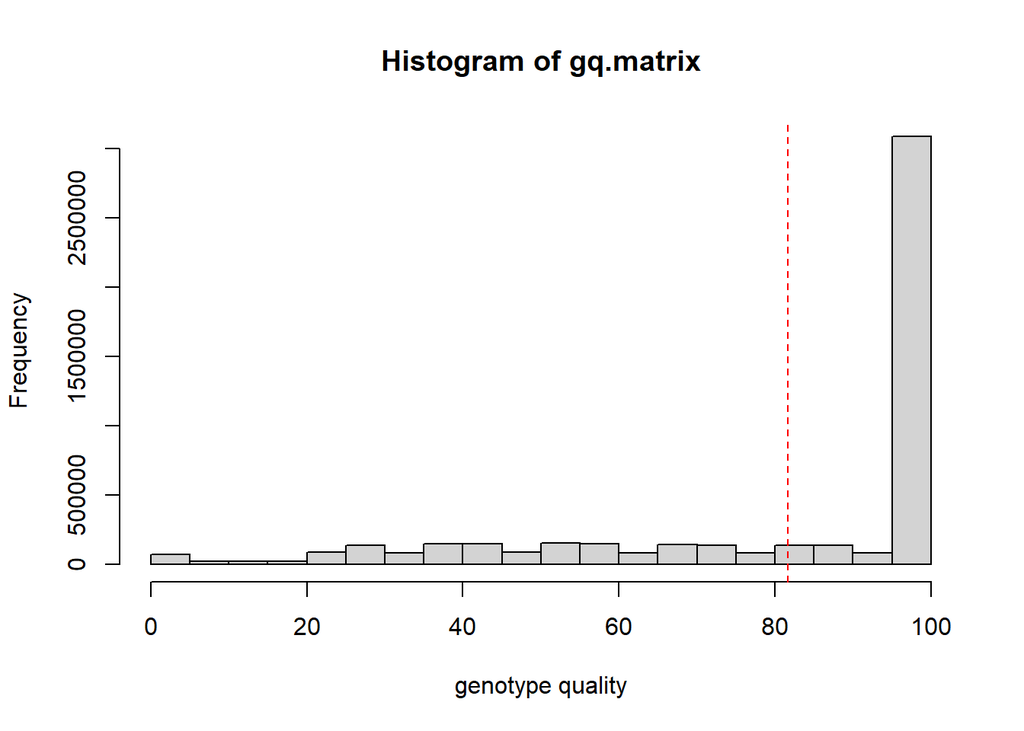

```
## 0.06% of SNPs were above a mean depth of 250 and were removed from the vcf
```

```
## 8.02% of het genotypes (1.74% of all genotypes) fall outside of 0.2 - 0.8 allele balance ratio and were converted to NA
```

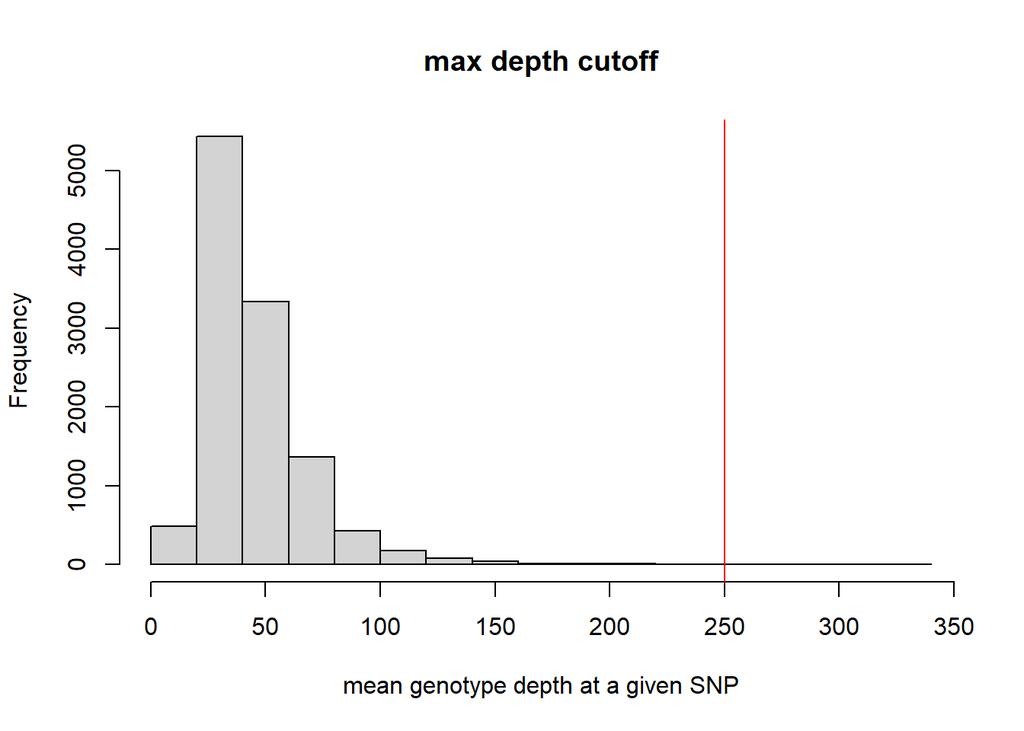

```
## cutoff is specified, filtered vcfR object will be returned
```

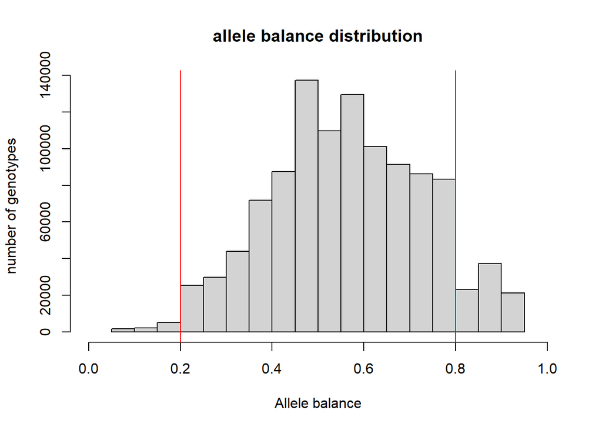

```
## 27.4% of SNPs fell below a completeness cutoff of 0.85 and were removed from the VCF
```

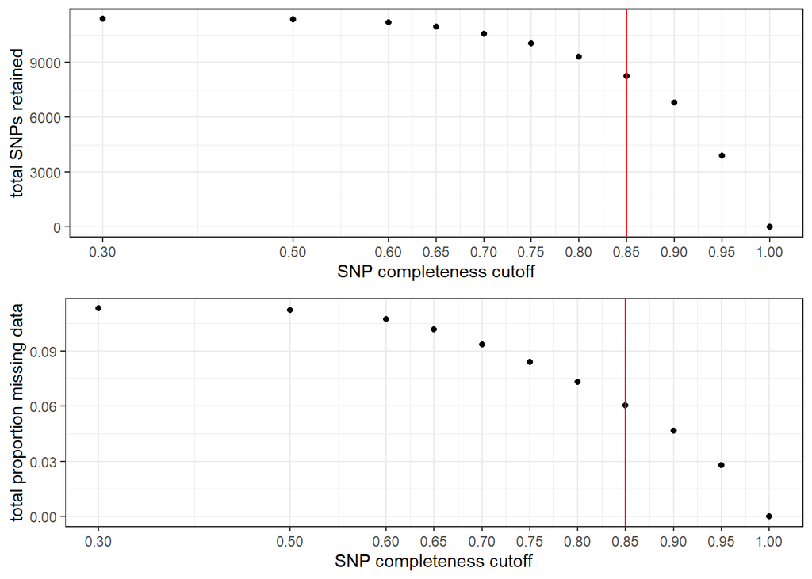

```
## 38 samples are above a 0.15 missing data cutoff, and were removed from VCF
```

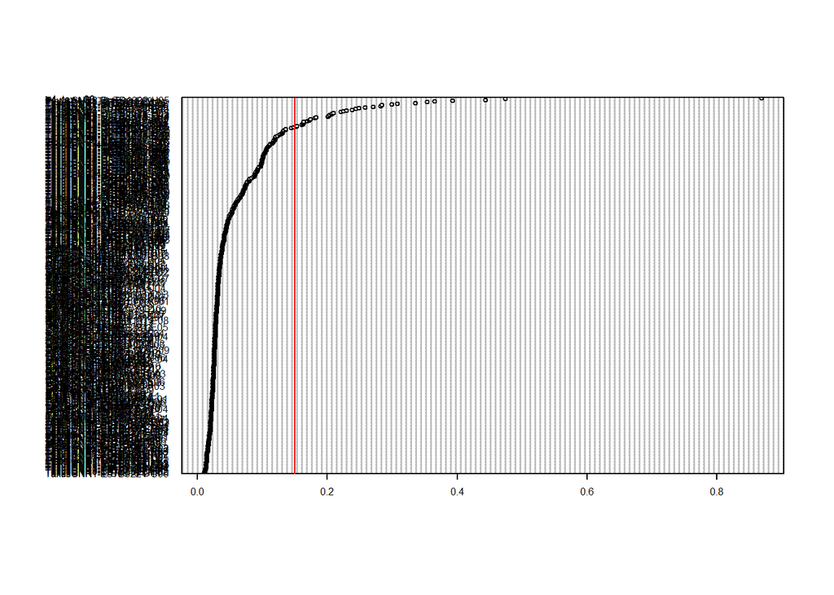

After filtering, we have 8252 SNPs, 452 samples and 4.37% of Na

- PCA

We are now changing the format of the vcf to fit the format for pca analysis First, we’re keeping only the genotype information from the vcfR

```r
vcf_data <- vcf_filter_structure %>%
  extract.gt(element="GT", IDtoRowNames = T, as.numeric=F) %>% t %>% data.frame
```

We also need to change the format of the dataset from nucleotide information to genotype

```r
#the format is in 0/0, 0/1 and 1/1 so we transform this in allele count

genetic_data_geno <- vcf_data %>%
  mutate_all(funs(str_replace(., "0/0", "0"))) %>%
  mutate_all(funs(str_replace(., "0/1", "1"))) %>%
  mutate_all(funs(str_replace(., "1/1", "2")))
```

To work at the population-level, we need to calculate allelic frequencies for each snp per population.

```r
#add VCF_ID but normally it will be in the imputated file
genetic_data_geno$VCF_ID <- row.names(genetic_data_geno)
#reduce the number of indiv in metadatavcf but normally it will be already done
meta_data_vcf_452 <- meta_data_vcf[meta_data_vcf$VCF_ID %in% genetic_data_geno$VCF_ID,]


#data for allelic frequencies
data_frequencies <-mutate(meta_data_vcf_452,genetic_data_geno,VCF_ID);row.names(data_frequencies) <- data_frequencies$VCF_ID
```

```r
#formatting the genomic data
data_frequencies_num <- data_frequencies[,-c(1:3)] %>% #keeping only the snps
  apply(2,as.numeric) /2 #we divided by 2 because of the format of genomic data: 0,1,2 and for allelic frequencies and we want 0,0.5, 1

#dataset with all information and genomic data in the right format
data_frequencies_num_tot <- data.frame(data_frequencies[,c(1:3)],data_frequencies_num)

#calculation of allelic frequencies
allelic_frequencies <-data_frequencies_num_tot %>% select(-c("VCF_ID","Country","Population")) %>% #remove non genomic data from the dataset
  group_by(data_frequencies_num_tot$Population) %>% #we want the allelic frequencies at the population level so we grouped
  summarise_at(vars(everything()),funs(mean),na.rm=T) %>% #calculate the mean for each snp per pop
  ungroup() %>%
as.data.frame()
```

Save the dataset of allelic frequencies

```r
#move population level to row.names
data_allelic_frequencies_29pop_adapcon_gentree <- allelic_frequencies %>% select(-c("data_frequencies_num_tot$Population")); row.names(data_allelic_frequencies_29pop_adapcon_gentree) <- allelic_frequencies$'data_frequencies_num_tot$Population'

#save

save(data_allelic_frequencies_29pop_adapcon_gentree,file="C:/Users/tfrancisco/Documents/Thèse/Data/Espèces/Taxus_baccata/genetic_new/data_allelic_frequencies_29pop_adapcon_gentree.Rdata")
```

```
                                     ######################
                                     #POPULATION STRUCTURE#
                                     ######################
```

```r
#load metadata
meta_data_vcf <- read.csv("C:/Users/tfrancisco/Documents/Thèse/Data/Espèces/Taxus_baccata/Samples/samples_taxus_baccata_adapcon_gentree.csv",h=T,sep=";",dec=",")

meta_data_pop <- read.csv("C:/Users/tfrancisco/Documents/Thèse/Data/Espèces/Taxus_baccata/Populations/taxus_sample_29pop.csv",h=T,sep=";",dec=",")
```

1. Individual-level

We first perform a screeplot analysis to see how much of the genetic variation is explained by the PCs axis.

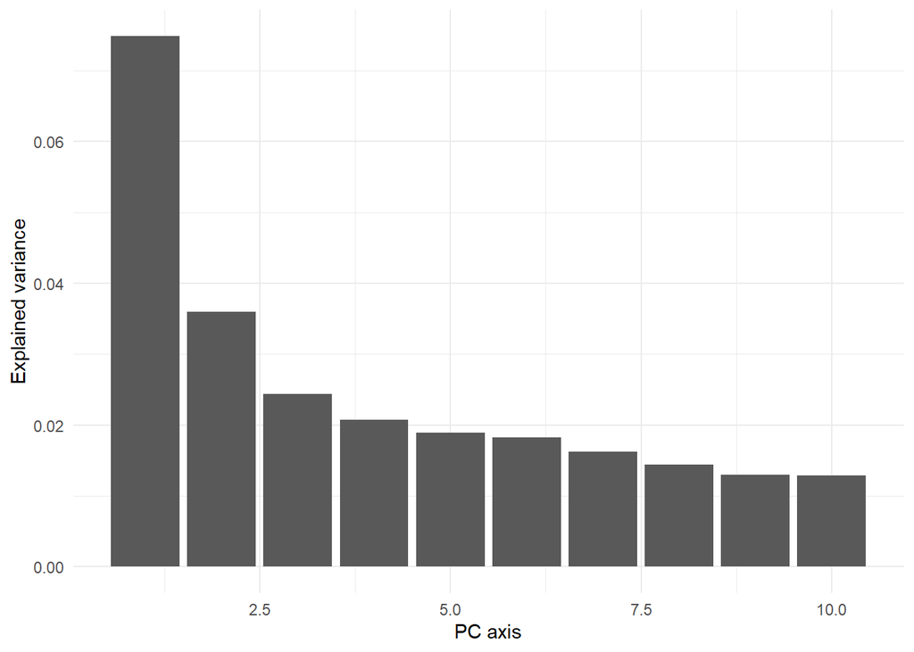

```r
#selection number of axis => screeplot
#initial parameters
load(file = "C:/Users/tfrancisco/Documents/Thèse/Data/Espèces/Taxus_baccata/genetic_new/structure/Dataset_PCA_8252SNP_452IND.Rdata")
gen_data_new <- Dataset_PCA_8252SNP_452IND[,-1]; row.names(gen_data_new)<- Dataset_PCA_8252SNP_452IND$VCF_ID
data <- gen_data_new
k <- 10

#function
screeplot_genetic <- function(data,k){

  data_PCa <- data  %>% dplyr::select(-c("na_percentage_indiv")) %>% t() %>% data.frame()
#format for pcadapt
data_pcadapt <- read.pcadapt(data_PCa)

#perform the Pca
Pcadapt_results <-pcadapt(data_pcadapt,K=k,method = "mahalanobis")

# choose the number of axis
 # Create ggplot object
 screeplot_data <- data.frame(
    PC_axis = seq_along(Pcadapt_results$singular.values),
    Explained_variance = Pcadapt_results$singular.values^2
  )

  gg_screeplot <- ggplot(screeplot_data, aes(x = PC_axis, y = Explained_variance)) +
    geom_bar(stat = "identity") +
    labs(x = "PC axis", y = "Explained variance") +
    theme_minimal()

  # Display the screeplot
  gg_screeplot
  print(gg_screeplot)
  return(Pcadapt_results)
        }
Pcadapt_object <- screeplot_genetic(data,k)
```

Interpretation: we keep the two first axis

Now, we run the PCA

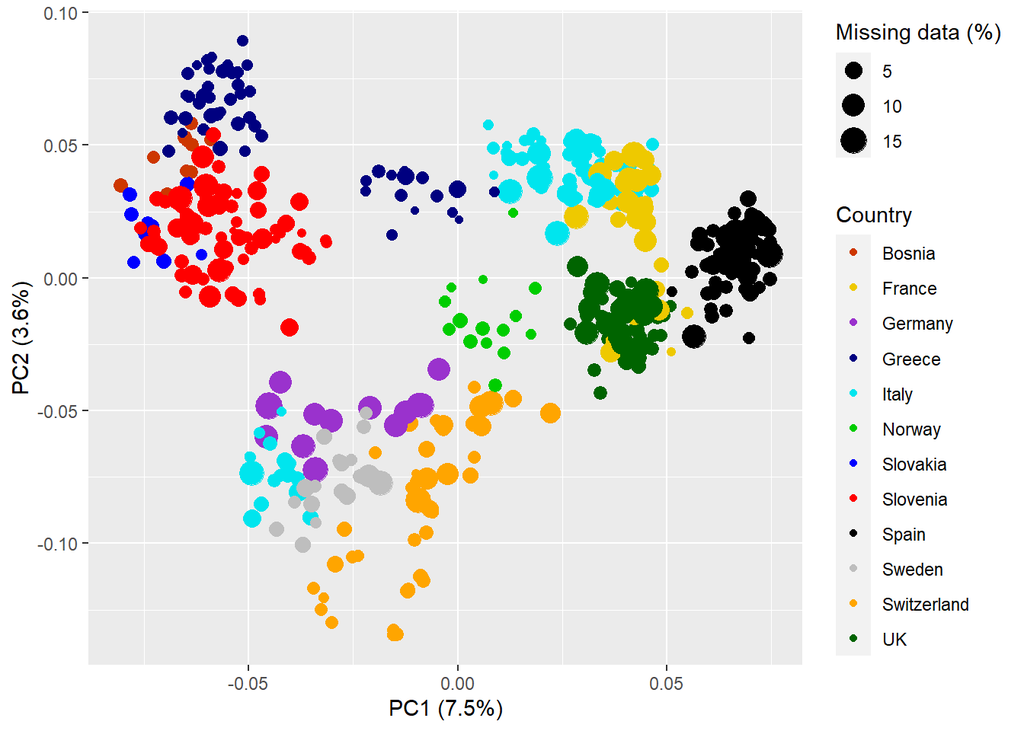

```r
#meta_data
meta_data_vcf_452 <- meta_data_vcf[meta_data_vcf$VCF_ID %in% row.names(gen_data_new),]

#Initial parameters
data <-Pcadapt_object #dataframe coming from the return of the screeplot_genetic function
names <- gen_data_new #initial dataframe
axis <- 2 #number of retained axis based on the screeplot
meta_data <- meta_data_vcf_452#meta data


#color per country

#for loop to do it for multiple PC axis like 1-2 but also 1-3, 2-3 etc
 Pca_genetic <- function(data, names, num_axes, meta_data) {
   #we can create 2 loops that would perform the Pca_function for each combination of axis retained:
  for (i in 1:(num_axes - 1)) { #here, the first loop will select axis between 1 and numb_axis-1 so basically, if we take 3 axis, i will take values of 1 then 2, so PCx will ether be 1 or 2.
    for (j in (i + 1):num_axes) { #here, the second loop within the first one will take the values of j from i +1 to num axis so if num axis=3, we will have j ranging from 2 to 3 when i=1 and j=3 when i =2
      #to summaries, the loops will perform the function for the combination of axis: 1-2,1-3 and 2-3 for 3 retained axis.

      PCx <- i
      PCy <- j

      # Calculate explained variance for chosen PCs
      explained_variance <- data.frame(t(round((data$singular.values[PCx:PCy]^2) * 100, digits = 1)))
      colnames(explained_variance) <- c("PCx", "PCy")

      #store the scores along the retained PC axis in a dataframe
      score_Pca_imputed <- data.frame(data$scores[, c(PCx,PCy)], row.names (names))
      colnames(score_Pca_imputed) <- c(paste0("PC", PCx), paste0("PC", PCy), "VCF_ID")

      # add country, population information
      PCa_df_imputed <- merge(score_Pca_imputed, meta_data, "VCF_ID")

      # genetic PCA
      ggplot_representation <- ggplot() +
        geom_point(data = PCa_df_imputed, aes(PCa_df_imputed[,2],PCa_df_imputed[,3],size = names$na_percentage, color = Country)) +
        scale_colour_manual(name = "Country",
                            values = c("orangered3", "gold2", "darkorchid3", "navyblue", "turquoise2", "green3", "blue", "red", "black", "gray", "orange", "darkgreen")) +
        scale_size(name = "Missing data (%)", breaks = c(0, 5, 10, 14), labels = c("0", "5", "10", "15")) +
        xlab(paste0("PC", PCx, " ", "(", explained_variance$PCx, "%", ")")) +
        ylab(paste0("PC", PCy, " ", "(", explained_variance$PCy, "%", ")"))

      print(ggplot_representation)
    }
  }
 }

#run the function
Pca_genetic(data,names,axis,meta_data)
```

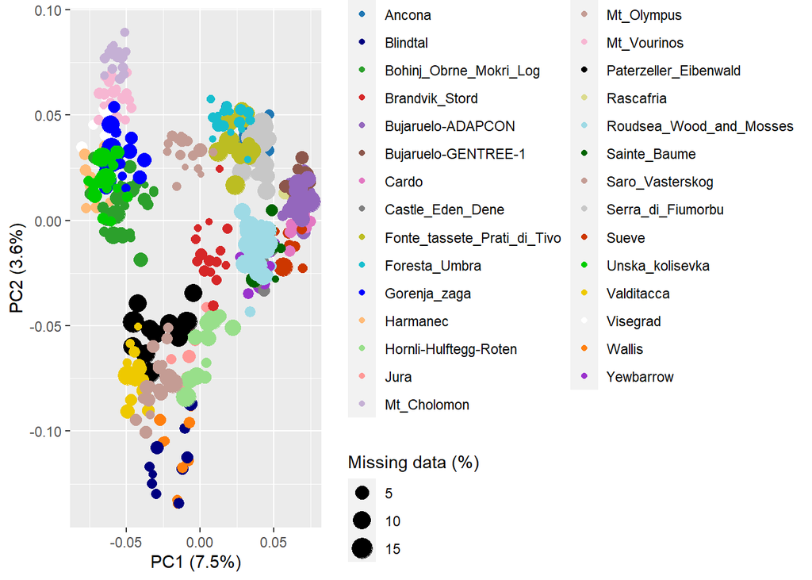

```
  - PCA with prcomp to see if there is differences depending on the methods
```

```r
#color per populations

Pca_genetic <- function(data, names, num_axes, meta_data) {
   #we can create 2 loops that would perform the Pca_function for each combination of axis retained:
  for (i in 1:(num_axes - 1)) { #here, the first loop will select axis between 1 and numb_axis-1 so basically, if we take 3 axis, i will take values of 1 then 2, so PCx will ether be 1 or 2.
    for (j in (i + 1):num_axes) { #here, the second loop within the first one will take the values of j from i +1 to num axis so if num axis=3, we will have j ranging from 2 to 3 when i=1 and j=3 when i =2
      #to summaries, the loops will perform the function for the combination of axis: 1-2,1-3 and 2-3 for 3 retained axis.

      PCx <- i
      PCy <- j

      # Calculate explained variance for chosen PCs
      explained_variance <- data.frame(t(round((data$singular.values[PCx:PCy]^2) * 100, digits = 1)))
      colnames(explained_variance) <- c("PCx", "PCy")

      #store the scores along the retained PC axis in a dataframe
      score_Pca_imputed <- data.frame(data$scores[, c(PCx,PCy)], row.names (names))
      colnames(score_Pca_imputed) <- c(paste0("PC", PCx), paste0("PC", PCy), "VCF_ID")

      # add country, population information
      PCa_df_imputed <- merge(score_Pca_imputed, meta_data, "VCF_ID")

      # genetic PCA
      ggplot_representation <- ggplot() +
        geom_point(data = PCa_df_imputed, aes(PCa_df_imputed[,2],PCa_df_imputed[,3],size = names$na_percentage, color = Population)) +
        scale_color_manual(name="Country", values=c("#1f77b4","navyblue", "#2ca02c", "#d62728", "#9467bd",
            "#8c564b", "#e377c2", "#7f7f7f", "#bcbd22", "#17becf",
            "blue", "#ffbb78", "#98df8a", "#ff9896", "#c5b0d5",
            "#c49c94", "#f7b6d2", "black", "#dbdb8d", "#9edae5",
            "darkgreen", "#c49c94", "#c7c7c7","orangered3","green3" ,
            "gold2","white", "#ff7f0e","darkorchid3" ))+
        scale_size(name = "Missing data (%)", breaks = c(0, 5, 10, 14), labels = c("0", "5", "10", "15")) +
        xlab(paste0("PC", PCx, " ", "(", explained_variance$PCx, "%", ")")) +
        ylab(paste0("PC", PCy, " ", "(", explained_variance$PCy, "%", ")"))

      print(ggplot_representation)
    }
  }
 }



#run the function
Pca_genetic(data,names,axis,meta_data)
```

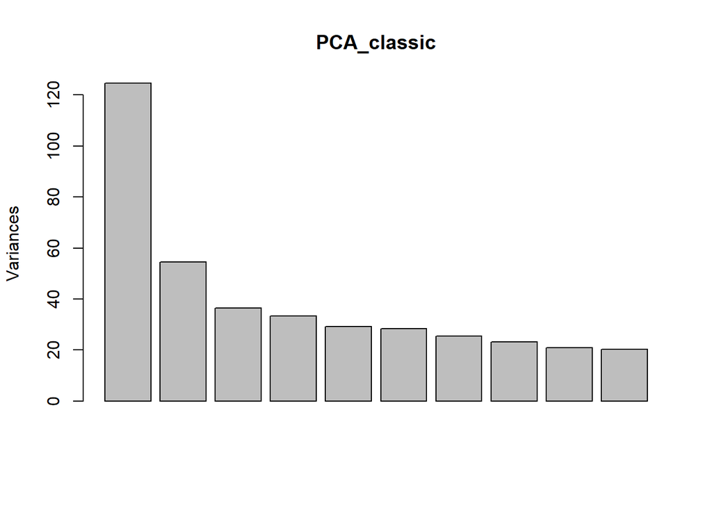

```r
#initial parameters
##file vcf_filtered_inputed from script genetic filtering because prcomp cannot deal with missing data
load("C:/Users/tfrancisco/Documents/Thèse/Data/Espèces/Taxus_baccata/genetic_new/vcf_filtered_inputed.Rdata")

data <- data.frame(apply(vcf_filtered_inputed, 2, as.numeric))
PCA_classic <- stats::prcomp(data)
plot(PCA_classic)
```

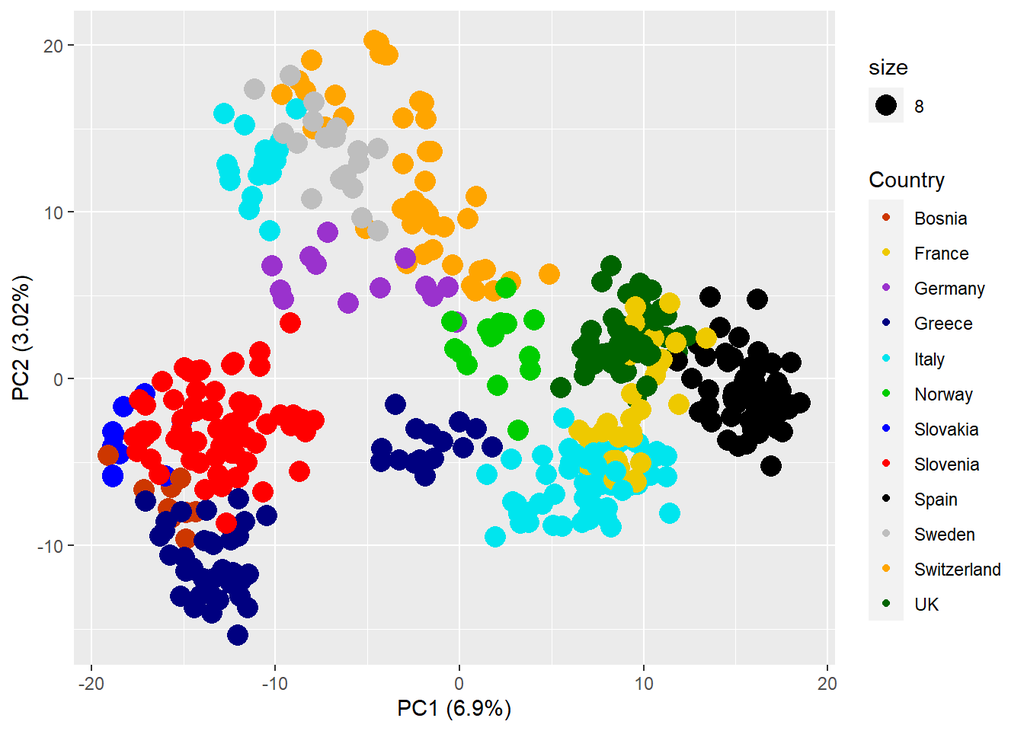

[output not shown]

```r
#explained variance
sum <- summary(PCA_classic)

#pca
      PCx <- 1
      PCy <- 2

      # Calculate explained variance for chosen PCs
      explained_variance <- data.frame(t(sum$importance[2,]))
      proportion_variance <- data.frame(explained_variance[c(PCx,PCy),] / sum(explained_variance) *100) %>% round(digit=2)
      proportion_variance_final <- proportion_variance[1,c(1,2)]
      colnames(proportion_variance_final) <- c("PCx", "PCy")

      #store the scores along the retained PC axis in a dataframe
      store_score_pca <- PCA_classic$x
      #add pop label
      store_score_pca_bis <- data.frame(row.names(vcf_filtered_inputed),store_score_pca)
      score_final_PCA <- data.frame(store_score_pca_bis[,c(1,2,3)]);colnames(score_final_PCA)=c("VCF_ID","PC1","PC2")
      #colnames(store_score_pca) <- c(paste0("PC", PCx), paste0("PC", PCy), "Population")

      # add country, population information
      PCa_df_imputed <- merge(score_final_PCA, meta_data, "VCF_ID")  #keep only the first row of each groups

      # genetic PCA
      ggplot_representation <- ggplot() +
        geom_point(data = PCa_df_imputed, aes(PCa_df_imputed[,2],PCa_df_imputed[,3],size=8, color = Country)) +
        scale_colour_manual(name = "Country",
                            values = c("orangered3", "gold2", "darkorchid3", "navyblue", "turquoise2", "green3", "blue", "red", "black", "gray", "orange", "darkgreen")) +
        xlab(paste0("PC", PCx, " ", "(", proportion_variance_final$PCx, "%", ")")) +
        ylab(paste0("PC", PCy, " ", "(", proportion_variance_final$PCy, "%", ")"))
      ggplot_representation
```

FIRST WAY: PCA at the population level

- PCADAPT

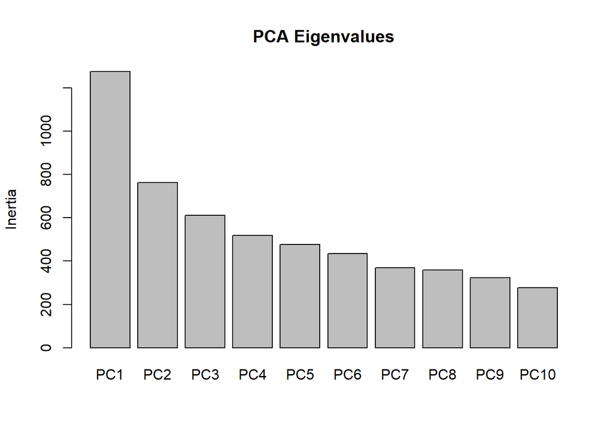

```r
load(file = "C:/Users/tfrancisco/Documents/Thèse/Data/Espèces/Taxus_baccata/genetic_new/data_allelic_frequencies_29pop_adapcon_gentree.Rdata")
gen_data_new <- data_allelic_frequencies_29pop_adapcon_gentree
data <- gen_data_new
k <- 10


#function
screeplot_genetic <- function(data,k){

#format for pcadapt

#perform the Pca
test <- rda(data, scale=T)
screeplot(test, type = "barplot", npcs=10, main="PCA Eigenvalues")

        }
Pcadapt_object <- screeplot_genetic(data,k)
```

```r
test <- rda(data, scale=T)
```

Interpretation: we keep the two first axis

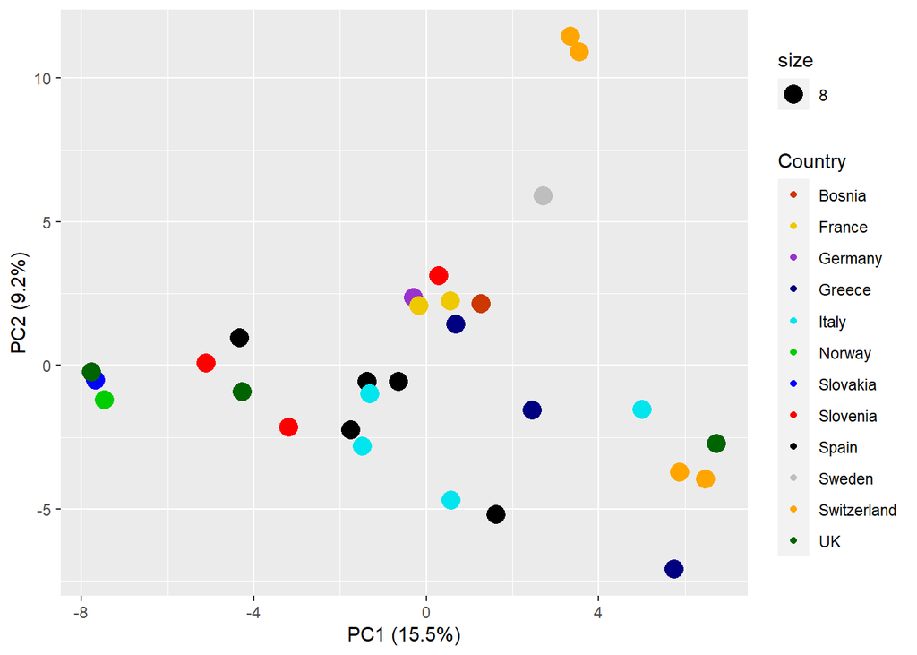

```r
meta_data_vcf_452 <- meta_data_vcf[meta_data_vcf$Population %in% row.names(gen_data_new),]

#Initial parameters
#data <-Pcadapt_object #dataframe coming from the return of the screeplot_genetic function

axis <- 2 #number of retained axis based on the screeplot
meta_data <- meta_data_vcf_452#meta data



#for loop to do it for multiple PC axis like 1-2 but also 1-3, 2-3 etc
 Pca_genetic <- function(data, names, num_axes, meta_data) {
   #we can create 2 loops that would perform the Pca_function for each combination of axis retained:
  for (i in 1:(num_axes - 1)) { #here, the first loop will select axis between 1 and numb_axis-1 so basically, if we take 3 axis, i will take values of 1 then 2, so PCx will ether be 1 or 2.
    for (j in (i + 1):num_axes) { #here, the second loop within the first one will take the values of j from i +1 to num axis so if num axis=3, we will have j ranging from 2 to 3 when i=1 and j=3 when i =2
      #to summaries, the loops will perform the function for the combination of axis: 1-2,1-3 and 2-3 for 3 retained axis.

      PCx <- i
      PCy <- j

      # Calculate explained variance for chosen PCs
      explained_variance <- data.frame(eigenvals(test))
      proportion_variance <- data.frame(t(explained_variance[c(PCx,PCy),] / sum(explained_variance) *100)) %>% round(digit=1)
      colnames(proportion_variance) <- c("PCx", "PCy")

      #store the scores along the retained PC axis in a dataframe
      store_score_rda <- scores(test, axes = c(PCx, PCy),display="sites" ) %>% data.frame(row.names(data))
      colnames(store_score_rda) <- c(paste0("PC", PCx), paste0("PC", PCy), "Population")

      # add country, population information
      PCa_df_imputed <- merge(store_score_rda, meta_data, "Population") %>% group_by(Population) %>% slice_head(n = 1) %>% ungroup() %>% as.data.frame()  #keep only the first row of each groups



      # genetic PCA
      ggplot_representation <- ggplot() +
        geom_point(data = PCa_df_imputed, aes(PCa_df_imputed[,2],PCa_df_imputed[,3],size=8, color = PCa_df_imputed$Country)) +
        scale_colour_manual(name = "Country",
                            values = c("orangered3", "gold2", "darkorchid3", "navyblue", "turquoise2", "green3", "blue", "red", "black", "gray", "orange", "darkgreen")) +
        xlab(paste0("PC", PCx, " ", "(", proportion_variance$PCx, "%", ")")) +
        ylab(paste0("PC", PCy, " ", "(", proportion_variance$PCy, "%", ")"))

      print(ggplot_representation)
    }
  }
 }

#run the function
Pca_genetic(data,names,axis,meta_data)
```

- PRCOMP

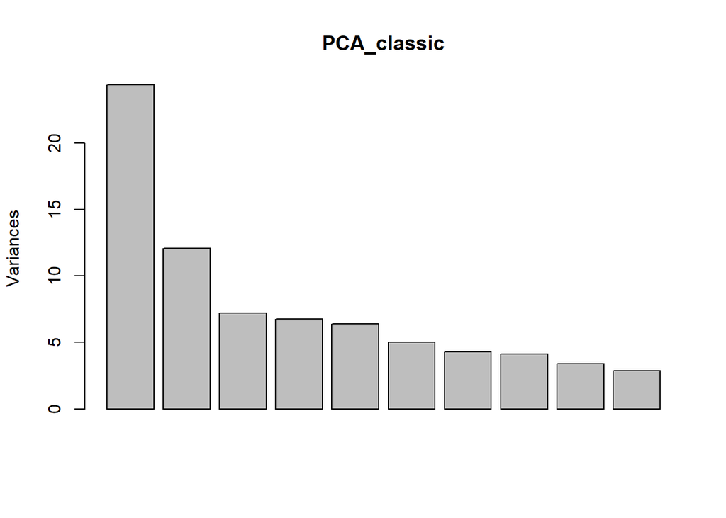

```r
#initial data
load(file = "C:/Users/tfrancisco/Documents/Thèse/Data/Espèces/Taxus_baccata/genetic_new/data_allelic_frequencies_29pop_adapcon_gentree.Rdata")
gen_data_new <- data_allelic_frequencies_29pop_adapcon_gentree
data <- gen_data_new
data_wo_na <- gen_data_new%>% select(-c("Tbac_contig_77917_326"))

#PCA
PCA_classic <- stats::prcomp(data_wo_na)
plot(PCA_classic)
```

```r
summ <- summary(PCA_classic)
summ
```

```
## Importance of components:
##                           PC1    PC2     PC3     PC4     PC5     PC6     PC7
## Standard deviation     4.9381 3.4777 2.68798 2.60207 2.52614 2.24125 2.07538
## Proportion of Variance 0.2395 0.1188 0.07097 0.06651 0.06268 0.04934 0.04231
## Cumulative Proportion  0.2395 0.3583 0.42929 0.49579 0.55848 0.60782 0.65013
##                            PC8     PC9    PC10    PC11    PC12    PC13    PC14
## Standard deviation     2.02720 1.84537 1.69158 1.57818 1.52234 1.43608 1.36885
## Proportion of Variance 0.04037 0.03345 0.02811 0.02446 0.02276 0.02026 0.01841
## Cumulative Proportion  0.69049 0.72394 0.75205 0.77651 0.79928 0.81953 0.83794
##                           PC15    PC16    PC17    PC18    PC19    PC20    PC21
## Standard deviation     1.35637 1.29460 1.24065 1.20421 1.17209 1.13732 1.10354
## Proportion of Variance 0.01807 0.01646 0.01512 0.01424 0.01349 0.01271 0.01196
## Cumulative Proportion  0.85601 0.87247 0.88759 0.90184 0.91533 0.92803 0.94000
##                           PC22    PC23    PC24    PC25    PC26    PC27    PC28
## Standard deviation     1.04806 1.01096 0.96313 0.94741 0.88142 0.85570 0.80864
## Proportion of Variance 0.01079 0.01004 0.00911 0.00882 0.00763 0.00719 0.00642
## Cumulative Proportion  0.95079 0.96083 0.96994 0.97875 0.98638 0.99358 1.00000
##                             PC29
## Standard deviation     3.458e-15
## Proportion of Variance 0.000e+00
## Cumulative Proportion  1.000e+00
```

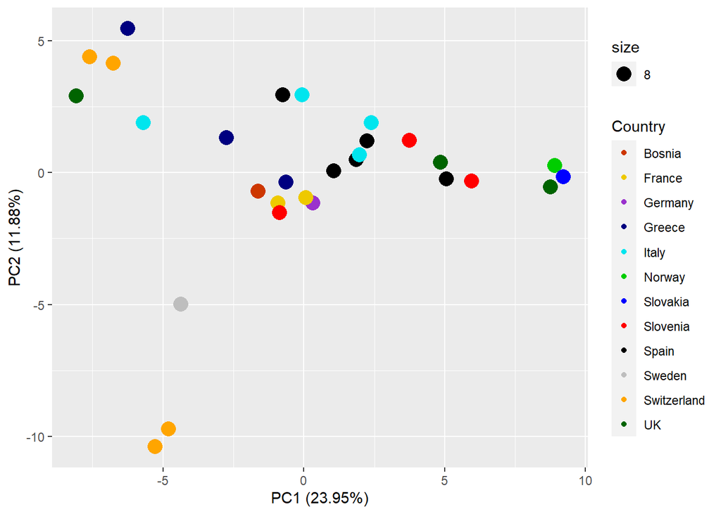

```r
#pca plot
      PCx <- 1
      PCy <- 2

      # Calculate explained variance for chosen PCs
       explained_variance <- data.frame(t(summ$importance[2,]))
      proportion_variance <- data.frame(explained_variance[c(PCx,PCy),] / sum(explained_variance) *100) %>% round(digit=2)
      proportion_variance_final <- proportion_variance[1,c(1,2)]

      #store the scores along the retained PC axis in a dataframe
      store_score_pca <- PCA_classic$x %>% data.frame()
      score_final_PCA <- data.frame(row.names(store_score_pca),store_score_pca[,c(1,2)]);colnames(score_final_PCA)=c("Population","PC1","PC2")
      colnames(store_score_pca) <- c(paste0("PC", PCx), paste0("PC", PCy), "Population")

      # add country, population information
      PCa_df_imputed <- merge(score_final_PCA, meta_data, "Population") %>% group_by(Population) %>% slice_head(n = 1) %>% ungroup() %>% as.data.frame()  #keep only the first row of each groups

      # genetic PCA
      ggplot_representation <- ggplot() +
        geom_point(data = PCa_df_imputed, aes(PCa_df_imputed[,2],PCa_df_imputed[,3],size=8, color = Country)) +
        scale_colour_manual(name = "Country",
                            values = c("orangered3", "gold2", "darkorchid3", "navyblue", "turquoise2", "green3", "blue", "red", "black", "gray", "orange", "darkgreen")) +
        xlab(paste0("PC", PCx, " ", "(", proportion_variance_final$PC1, "%", ")")) +
        ylab(paste0("PC", PCy, " ", "(", proportion_variance_final$PC2, "%", ")"))
      ggplot_representation
```